# E02 - Intro to Rmd (Analysis of Gene Expression @ UCT Prague)

Jiri Novotny jiri.novotny@img.cas.cz

Studuj bioinformatiku! http://studuj.bioinformatiku.cz

2022-02-16

# RMarkdown (Rmd)

Code chunks in RMarkdown document are evaluated by [knitr](https://yihui.name/knitr/) and their output converted to [Markdown](https://pandoc.org/MANUAL.html#pandocs-markdown), which is then compiled by [pandoc](https://pandoc.org) to selected output format (in our case HTML). All of this is handled automatically by `rmarkdown::render()` function (see the “How to render RMarkdown documents” section).

**Useful links**

- [How RMarkdown works](https://uclouvain-cbio.github.io/WSBIM1207/sec-rr.html)
- [R Markdown: The Definitive Guide](https://bookdown.org/yihui/rmarkdown/)
- [RMarkdown cheatsheet](https://rmarkdown.rstudio.com/lesson-15.html) (PDF [here](https://raw.githubusercontent.com/rstudio/cheatsheets/master/rmarkdown-2.0.pdf) and [here](https://rstudio.com/wp-content/uploads/2015/03/rmarkdown-reference.pdf))
- [RMarkdown cookbook](https://bookdown.org/yihui/rmarkdown-cookbook/)
- [Markdown cheatsheet](https://github.com/adam-p/markdown-here/wiki/Markdown-Cheatsheet)
- [pandoc’s Markdown flavour](https://pandoc.org/MANUAL.html#pandocs-markdown)
- [knitr options](https://yihui.name/knitr/options/)
- [RMarkdown output formats](https://rmarkdown.rstudio.com/lesson-9.html)

> After you finish the Rendering RMarkdown section, the best way to familiarize yourself with RMarkdown will be to create a new Rmd file and try to use the Markdown syntax, to create code chunks, to modify the header, and to render the Rmd file to HTML.

# How to write RMarkdown documents

Files with `.Rmd` extension are recognized by RStudio, which automatically adapts its environment to them (notebook mode).

**Pandoc header**

On the beginning of the source file you can see the header section separated by `---`. Those are options for `pandoc`, mostly specifying how output should look like. They are written in [YAML format](https://lzone.de/cheat-sheet/YAML).

You can see we are using three common parameters: `title`, `author` and `institute`. The first two will be shown in the header of the resulting HTML document.

As the output type we are using `html_document` with several parameters:

- `toc: true`: make a Table of Contents.
- `toc_depth: 4`: how many section levels to show in the TOC.
- `toc_float: true`: make the TOC floating on the left side of page. If `false`, TOC will be placed statically to the beginning of document.
- `df_print: paged`: default output style for tables.

For possible output types see [this](https://rmarkdown.rstudio.com/lesson-9.html) overview with links to R Markdown: The Definitive Guide.

It is also possible to use inline R code in parameters. As an example, we used this to output the current date:

```r
date: "`r Sys.Date()`"
```

**Markdown syntax**

Markdown is an easy-to-write/easy-to-read markup language (see the source of this document). It is widely used by, but not only, developers for documentation (you have certainly seen it on GitHub). Markdown syntax is super easy and so, please, refer to [Markdown cheatsheet](https://github.com/adam-p/markdown-here/wiki/Markdown-Cheatsheet) (however, `pandoc` uses an [extended version](https://pandoc.org/MANUAL.html#pandocs-markdown) of Markdown).

Some examples:

`**This is a bold text.**`

**This is a bold text.**

`*This is a text in italics.*`

*This is a text in italics.*

`This is code markup.`

```
This is multiline code markup.
```

`# This is a section header of level 1`

`## This is a section header of level 2 (a subsection of the header above)`

```
- List item 1.
- List item 2.
  - Sublist of item 2.
```

- List item 1.
- List item 2.
  - Sublist of item 2.

```
1. First item.
2. Second item.
    - Sublist of second item.
```

1. First item.
2. Second item.
   - Sublist of second item.

```
<!-- Comment outside of code chunk. -->
<!--
Multiline comment
outside of code chunk.
-->
```

[figure not shown]

Markdown example in RStudio.

**Using HTML tags**

Besides Markdown syntax, you can use anything you would normally use in HTML. For example, `<div style="color: red;">Some red text.</div>`:

Some red text.

Just be careful, because RMarkdown is not a classic HTML document and you don’t have a full control over conversion to output HTML.

**Code chunks**

Code (R, Python, etc.) is placed in [chunks](https://bookdown.org/yihui/rmarkdown/r-code.html). A chunk begins with triple backticks followed by `{language_name}` and ends with another triple backticks. Both start and end triple backticks must be on separate lines.

Example of chunk with R code:

````r
```{r}
df <- data.frame()
```
````

Output from a chunk is generated below the chunk.

Each chunk can have options set. For example,

````r
```{r, warning = FALSE}
df <- data.frame()
```
````

will suppress all warnings produced by this chunk. See [knitr options](https://yihui.name/knitr/options/).

You can set these options globally via `opts_chunk$set()` function from `knitr` package. For example, this will suppress warnings from all chunks, but individual chunks can override this option:

```r
library(knitr)
opts_chunk$set(warning = FALSE)
```

JavaScript and CSS are also [supported](https://bookdown.org/yihui/rmarkdown/language-engines.html#javascript-and-css). Code in chunks of type `js` and `css` will be put to `<script>` and `<style>` tags inside `<head>`.

**Inline code**

You can also place R code [inline](https://rmarkdown.rstudio.com/lesson-4.html) using `` `r code` ``. Inline code in final document will be replaced by its output.

**Notebook mode**

In Rstudio, you use RMarkdown documents as so-called [notebooks](https://bookdown.org/yihui/rmarkdown/notebook.html). That is, each code chunk can be evaluated in current R session. Let’s see some examples (run them in your RStudio):

```r
head(mtcars, n = 20)
```

|  | mpg | cyl | disp | hp | drat | wt | qsec | vs | am | gear | carb |
| --- | --- | --- | --- | --- | --- | --- | --- | --- | --- | --- | --- |
| Mazda RX4 | 21.0 | 6 | 160.0 | 110 | 3.90 | 2.620 | 16.46 | 0 | 1 | 4 | 4 |
| Mazda RX4 Wag | 21.0 | 6 | 160.0 | 110 | 3.90 | 2.875 | 17.02 | 0 | 1 | 4 | 4 |
| Datsun 710 | 22.8 | 4 | 108.0 | 93 | 3.85 | 2.320 | 18.61 | 1 | 1 | 4 | 1 |
| Hornet 4 Drive | 21.4 | 6 | 258.0 | 110 | 3.08 | 3.215 | 19.44 | 1 | 0 | 3 | 1 |
| Hornet Sportabout | 18.7 | 8 | 360.0 | 175 | 3.15 | 3.440 | 17.02 | 0 | 0 | 3 | 2 |
| Valiant | 18.1 | 6 | 225.0 | 105 | 2.76 | 3.460 | 20.22 | 1 | 0 | 3 | 1 |
| Duster 360 | 14.3 | 8 | 360.0 | 245 | 3.21 | 3.570 | 15.84 | 0 | 0 | 3 | 4 |
| Merc 240D | 24.4 | 4 | 146.7 | 62 | 3.69 | 3.190 | 20.00 | 1 | 0 | 4 | 2 |
| Merc 230 | 22.8 | 4 | 140.8 | 95 | 3.92 | 3.150 | 22.90 | 1 | 0 | 4 | 2 |
| Merc 280 | 19.2 | 6 | 167.6 | 123 | 3.92 | 3.440 | 18.30 | 1 | 0 | 4 | 4 |

[output cut: 10 more lines]

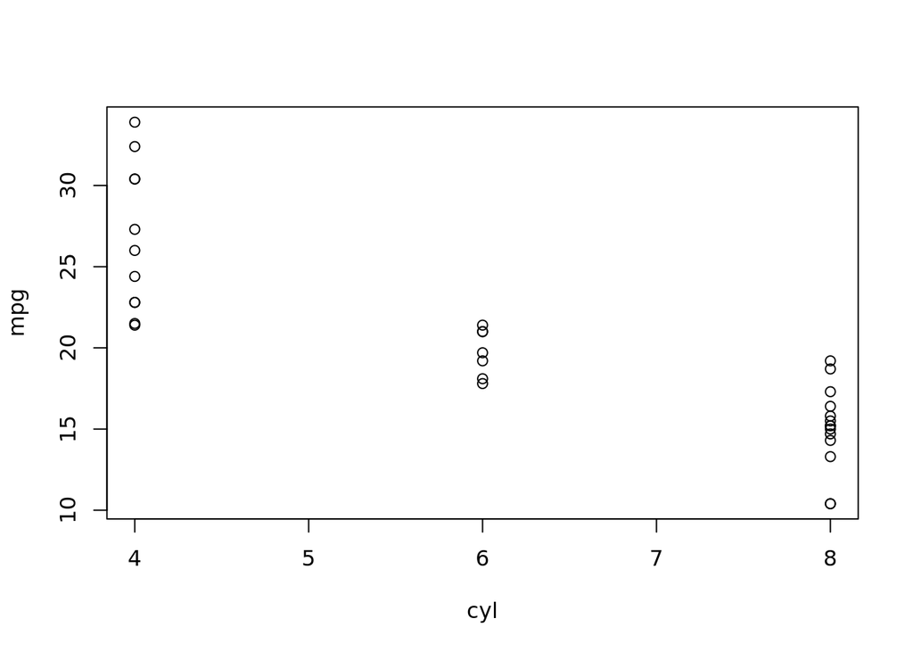

```r
plot(mpg ~ cyl, data = mtcars)
```

**Rendering a document**

See this section below.

## Useful Rmd-related keyboard shortcuts in RStudio

You can view them in `Tools -> Keyboard Shortcuts Help`.

- `Ctrl + Enter`: run current line or selected lines.
- `Ctrl + Alt + R`: run all chunks.
- `Ctrl + Alt + P`: run all chunks above.
- `Ctrl + Shift + Enter`: run current chunk.
- `Ctrl + Alt + N`: run next chunk.

# How to render RMarkdown documents

To render a Rmd file, use the `rmarkdown::render()` function. Below you can find a code chunk, which loads the `knitr` and `here` packages, sets global chunk options and renders this Rmd file to HTML. **It is a good practice to:**

- Specify `envir = new.env()` - this will render the Rmd file in a new R environment, so your current variables won’t interfere.
- Run `opts_knit$set(root.dir = here::here())` before `render()` - this sets R working directory to the project’s root during the rendering. Alternatively, use the `knit_root_dir` parameter in `render()`. More details about this are given in the next section.

```r
library(knitr)
library(here)

# You can set global chunk options. Options set in individual chunks will override this.
opts_chunk$set(warning = FALSE, message = FALSE, eval = TRUE)
rmarkdown::render(
  here("E02-intro_to_R/intro_to_Rmd.Rmd"),
  output_file = here("E02-intro_to_R/intro_to_Rmd.html"),
  envir = new.env(),
  knit_root_dir = here(),
  clean = FALSE
)
```

Because `clean = FALSE` in `rmarkdown::render()`, intermediate Markdown (`.md`) files are not removed and you have an opportunity to inspect them. These files are sources for `pandoc`, which does the actual rendering to HTML format (as specified in the header of this Rmd file, but `pandoc` can render to many other formats than HTML, e.g. PDF or LaTex).

We can also override output format specified in Rmd header by passing `output_format` to `rmarkdown::render()`. Let’s try it and render this document in a popular “Tufte handout style”:

```r
rmarkdown::render(
    here("E02-intro_to_R/intro_to_Rmd.Rmd"),
    output_file = here("E02-intro_to_R/intro_to_Rmd_tufte.html"),
    output_format = "tufte::tufte_html",
    envir = new.env(),
    knit_root_dir = here()
)
```

> Now when you know the RMarkdown basics and how to render it to HTML, you can try yourself to create a Rmd file and play with it: use the Markdown syntax, create code chunks, modify the header, and render it to HTML.

## Working directory in Rmd files

By default, RMarkdown code chunks in RStudio and in `render()` are evaluated in the directory of opened Rmd file (`Exercise/E02-intro_to_R` for this one), whereas your working directory in R terminal is a project’s root directory (`Exercises/`). That is really annoying, because we want a consistent navigation relative to the project’s root directory.

To prevent these working directory discrepancies:

- In RStudio:

[figure not shown]

RMarkdown code chunks should be evaluated in the project’s root directory.

- For `render()`, run `opts_knit$set(root.dir = here::here())` before or use the `knit_root_dir` parameter in `render()`, e.g. `render(..., knit_root_dir = here::here())`.

**For more details, be sure to check out the `E02 - Intro to R / Reproducible R` section.**

# Some RMarkdown tips

## Do not run heavy computations inside RMarkdown documents

RMarkdown documents should be used for reporting of your results that are calculated in separate script/s. Otherwise you have to render a whole document again no matter how small code/data changes you make.

## Pretty tables

You have several choices how tables will be printed. This is set via the `df_print` parameter under `html_document`. See [here](https://bookdown.org/yihui/rmarkdown/html-document.html#data-frame-printing) for possible choices. Anyway, several alternatives exist:

We can use [DT](https://rstudio.github.io/DT/) package, an R interface to JavaScript library [datatables](https://datatables.net/).

```r
DT::datatable(
  mtcars[, 1:5],
  filter = "top",
  class = "display",
  rownames = TRUE
)
```

|  | mpg | cyl | disp | hp | drat |
| --- | --- | --- | --- | --- | --- |
| Mazda RX4 | 21 | 6 | 160 | 110 | 3.9 |
| Mazda RX4 Wag | 21 | 6 | 160 | 110 | 3.9 |
| Datsun 710 | 22.8 | 4 | 108 | 93 | 3.85 |
| Hornet 4 Drive | 21.4 | 6 | 258 | 110 | 3.08 |
| Hornet Sportabout | 18.7 | 8 | 360 | 175 | 3.15 |
| Valiant | 18.1 | 6 | 225 | 105 | 2.76 |
| Duster 360 | 14.3 | 8 | 360 | 245 | 3.21 |
| Merc 240D | 24.4 | 4 | 146.7 | 62 | 3.69 |
| Merc 230 | 22.8 | 4 | 140.8 | 95 | 3.92 |
| Merc 280 | 19.2 | 6 | 167.6 | 123 | 3.92 |

[output cut: 22 more lines]

Or [kable](https://bookdown.org/yihui/rmarkdown-cookbook/kable.html) and [kableExtra](https://cran.r-project.org/web/packages/kableExtra/vignettes/awesome_table_in_html.html) for simplier, but still pretty tables:

```r
kableExtra::kable_styling(
  kableExtra::kbl(head(mtcars)),
  bootstrap_options = c("striped", "hover", "condensed")
)
```

|  | mpg | cyl | disp | hp | drat | wt | qsec | vs | am | gear | carb |
| --- | --- | --- | --- | --- | --- | --- | --- | --- | --- | --- | --- |
| Mazda RX4 | 21.0 | 6 | 160 | 110 | 3.90 | 2.620 | 16.46 | 0 | 1 | 4 | 4 |
| Mazda RX4 Wag | 21.0 | 6 | 160 | 110 | 3.90 | 2.875 | 17.02 | 0 | 1 | 4 | 4 |
| Datsun 710 | 22.8 | 4 | 108 | 93 | 3.85 | 2.320 | 18.61 | 1 | 1 | 4 | 1 |
| Hornet 4 Drive | 21.4 | 6 | 258 | 110 | 3.08 | 3.215 | 19.44 | 1 | 0 | 3 | 1 |
| Hornet Sportabout | 18.7 | 8 | 360 | 175 | 3.15 | 3.440 | 17.02 | 0 | 0 | 3 | 2 |
| Valiant | 18.1 | 6 | 225 | 105 | 2.76 | 3.460 | 20.22 | 1 | 0 | 3 | 1 |

Another interesting package for publication-quality tables is [gt](https://gt.rstudio.com/index.html) (and at the bottom of its homepage you can find a nice list of other table-related packages). This [case study](https://gt.rstudio.com/articles/case-study-gtcars.html) will show you all `gt` features.

## Using tab design

As you can see, this document has autogenerated TOC menu on the left. However, you can also use a tab-style menu. See the `tab_design.Rmd` (HTML) example.

Personally, I have found this design very useful for reporting.

## Generating Markdown and HTML from R

The cool feature of code chunks is also the ability of **raw** output, by setting `results = "asis"`. For example, this chunk produces a Markdown header and some text below:

````r
```{r, results = "asis"}
cat("\n\n#### I am an example header\n")
cat("\nHello world!\n\n")
```
````

#### I am an example header

Hello world!

I have found this to be very useful for dynamic reports, e.g. header names are composed from sample groups.

## [flexdashboard](https://rmarkdown.rstudio.com/flexdashboard/index.html) - easy interactive dashboards for R

[flexdashboard](https://rmarkdown.rstudio.com/flexdashboard/index.html) is awesome package for dashboard-style reporting. You can find a quick example [here](https://beta.rstudioconnect.com/jjallaire/htmlwidgets-ggplotly-geoms/htmlwidgets-ggplotly-geoms.html#geom_density).

## RMarkdown themes

You can see that this Rmd document has a different theme than the others used for exercises (those are using `readthedown` theme from rmdformats package).

Using different themes is quite easy and you can refer to [this nice overview](https://www.datadreaming.org/post/r-markdown-theme-gallery/). Several themes are included in `rmarkdown` package. Because we didn’t specify `theme` parameter under `html_document` in header (see [here](https://bookdown.org/yihui/rmarkdown/html-document.html#appearance-and-style)), just now we are using a default theme called simply `default`. You can try to change the theme to e.g. `united` and render this document again 🙂